# Entity-Relationship Model

## Legend

- Rectangles: entity sets (table)
  - Double rectangle: weak entity set (table with column for primary key of identifying strong entity set)
- Ellipses: attributes of the entity (column in table)
  - Double ellipse: multi-valued attribute (separate table)
  - Dashed ellipse: derived attribute
  - Child ellipses: composite attributed (column in table)
- Diamonds: Relationship sets (between entities)
  - Relational Table:
    - many-to-many: seperate table with primary keys of participating entity sets
    - many-to-one: if 'many' is total, add the primary key of the 'one'
    - one-to-one: use many-to-one, where either side can be the 'many'
  - Double diamond: identifying relationship
- Triangle: Specialization relationship
  - Relational Table: either
    - Table containing primary key of the higher-level entity set and local attributes)
    - Table with all local and inherited attributes
      - PRO: Efficient data retrival
      - CON: Storage redundancy
- Directed Line (->): one
- Undirected Line (--): many
- Double line (=): total relationship
- Single line (-): partial relationship
- Underline: Primary key
  - Dotted underline: weak set identifier
- Disjoint label: disjoint specialization

## Entity and Entity set

- Entity: an object
  - e.g Customer, Account
- Attribute: something an entity has
  - e.g Customers have names
- Entity set: set of entities of the same type that share the same properties
  - Represents a table with the same attributes
  - e.g All Customers
- Relationship: association among entities
- Relationship set: set of relationships of the same type
  - Diamond with relationship type

## Constraints

### Mapping cardinalities

- Directed Line (->): one
- Undirected Line (--): many

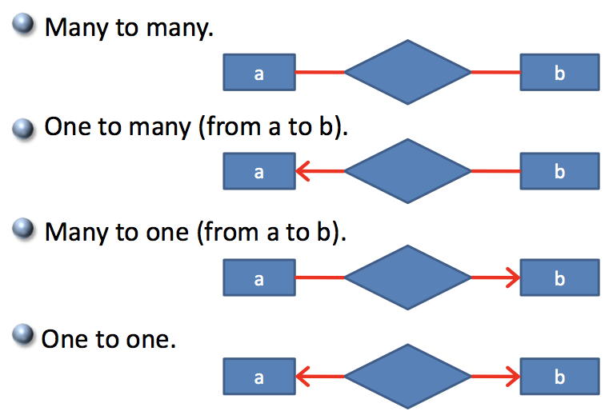

### Participation constraints

- Total participaction (=): every entity participates in at least one relationship
- Partial participation (-): some entity may not participate in any relationship

## Keys

- Super key: set of one or more attributes that uniquely determine each entity
  - e.g {user_id, name}
- Candidate key: minimal (no subset super key exists) super key
  - e.g {user_id}
- Primary key (underlined): the candidate key selected to be the primary key

## Different Attribute Types

- Single vs Composite attributes (child ellipses)
  - Composite attributes are made of multiple attributes
  - e.g Address = {street, city, state}
- Single-valued vs Multi-valued attributes (double ellipses)
  - e.g Multiple phone numbers
  - Don't actually use this
- Derived attribute (dashed ellipses)
  - Values derived from other attributes
  - e.g age derived from date_of_birth

## Weak Entity Set

- Represented by a double rectangle
- Entity set that does not have a primary key
- Must have a total, many-to-one identifying relationship set (double diamond) to the identifying entity set
- Discriminator (dotted underline): identifies entities within the weak set
- e.g Player's number is only unique within their team

## Role

- Relationship between entities in the same entity set
- Labeled with the different roles of the relationship

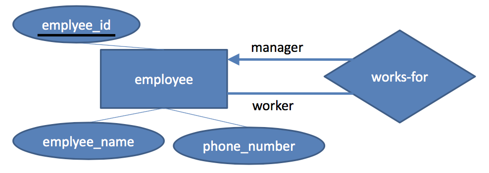

## Specialization

- Represented by a Triangle with relationship type (e.g ISA)
- Lower-level entity set that inherits all attributes and relationships of the higher level entity set
- Can also have its own attributes
- e.g Student can be full-time or part-time
- Disjoint vs Overlapping
  - Disjoint: entities can only belong to one specialization

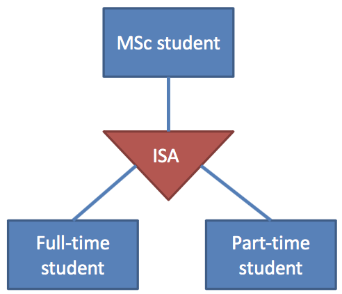

# Structured Query Language

- Language for defining, modifying and querying data
- Declarative (states what we want, not how)

## Data Definition

### Table Creation

```sql
CREATE TABLE table_name
(
    column1_name column_type CONDITIONS,
    ...
    CONSTRAINTS
);
```

- Conditions: `NOT NULL`
- Constraints:
  - `PRIMARY KEY(column_name)`
  - `FOREIGN KEY(column_name) REFERENCES table_name(key)`

### Table Deletion

```sql
DROP TABLE table_name;
```

- Drop instruction may be rejected if table is referenced by other tables via constraints

### Table Modification

```sql
ALTER TABLE table_name ADD column_name;
ALTER TABLE table_name DROP column_name;
ALTER TABLE table_name ADD CONSTRAINT;
```

## Insert, Delete, Update

### Insert

```sql
INSERT INTO table_name VALUES
    (column1_value, column2_value, column3_value) -- row 1
    (column1_value, column2_value, column3_value) -- row 2
    ;
LOAD DATA LOCAL INFILE 'file.txt'
    INTO TABLE table_name
    FIELDS TERMINATED BY ','
    LINES TERMINATED BY '\n';
```

### Delete

```sql
DELETE FROM table_name; -- Delete all records
DELETE FROM table_name WHERE column_name = 'test_value';
```

### Update

```sql
UPDATE table_name
    SET column1_name = 'value'
    WHERE column2_name = 'test_value';

UPDATE table_name
    SET column1_name = column1_name * 10;

UPDATE table_name
    SET column_name = CASE
        WHEN column_name <=500 THEN column_name * 1.05
        ELSE column_name * 1.06
        END;
```

## Querying

### Select

```sql
SELECT * FROM table_name; -- all columns
SELECT column_name FROM table_name;
SELECT name, amount * 2 FROM table; -- can do math

-- conditions
SELECT table1.column_name FROM table1, table2
    WHERE table1.property = table2.property;
SELECT cost FROM table1
    WHERE cost >= 100 AND seller = 'Kelly';

-- distinct
SELECT DISTINCT column_name FROM table_name;

-- renaming
SELECT column_name AS alias FROM table_name T;
```

### String Operations

```sql
WHERE name LIKE 'J% D%';
```

- `%` matches any substring
- `_` matches any character

### Ordering

```sql
ORDER BY column_name ASC;
ORDER BY column_name DESC;
```

### Nesting

```sql
-- IN, SOME, ALL, EXISTS
SELECT a FROM t
WHERE id IN (
    SELECT user_id FROM users
);
```

### Aggregation

```sql
-- AVG MIN MAX SUM COUNT
SELECT AVG(column_name) FROM table_name;
SELECT user_id, AVG(balance)
    FROM users
    GROUP BY user_id
    HAVING AVG(balance) >= 100;
```

### Join

```sql
-- OUTER JOIN, INNER JOIN, CROSS JOIN
SELECT * FROM t1 JOIN t2
    ON t1.id = t2.id;
```

### Null

- `value IS NULL`
- `(5 + null) == null)`
- `(null = null) == UNKNOWN`

## Views

```sql
CREATE VIEW view_name AS (<query>)
```

- Mechanism to hide certain data from certain users

## Authorization

```sql
GRANT privilege ON table_name TO user_or_role;
REVOKE privilege ON table_name FROM user_or_role;

CREATE ROLE role_name;
GRANT role_name TO user_name;
```

## Assertions

```sql
CREATE ASSERTION assertion_name
CHECK (
    (SELECT COUNT(*) FROM t1) <= (SELECT COUNT(*) FROM t2)
);
```

- Checked everytime the table is updated

# Relational Algebra

- Algebra with tables (relations) as operand, and new operators
- Models lower-level operations of a relational DBMS

## Basic Operators

| Symbol | Name | Description | Example |
| --- | --- | --- | --- |
| σ | Select | Filter on a condition | *σ*<sub>name="May"</sub>(Author) |
| π | Projection | Copy with fewer attributes | *π*<sub>id, name</sub>(Users) |
| ∪ | Union | Combine two sets with the same attributes | *π*<sub>name</sub>(Students)∪*π*<sub>name</sub>(Teachers) |
| - | Set difference | Difference of two sets with the same attributes | *π*<sub>id</sub>(Students)−*π*<sub>id</sub>(Enrolled) |
| × | Cartesian product | Join of all possible combinations | $Items × Orders$ |
| ρ | Rename | Rename a table | *ρ*<sub>c</sub>(Course) |

## Additional Operators

[output not shown]

## Extended Operators

[output not shown]

### Aggregation

- avg, min, max, sum, count, count-distinct
- <sub>*G*<sub>1</sub>, *G*<sub>2</sub></sub>g<sub>*F*<sub>1</sub>(*A*<sub>1</sub>),*F*<sub>2</sub>(*A*<sub>2</sub>)</sub>(R)
  - *G*<sub>1</sub>, *G*<sub>2</sub> = attributes to group by
  - *F*<sub>1</sub>(*A*<sub>1</sub>),*F*<sub>2</sub>(*A*<sub>2</sub>) = aggregate functions to apply

## Algebraic Properties

### Equivalence Rules

1. *π*<sub>1</sub>(*π*<sub>2</sub>(…(*π*<sub>*n*</sub>(*E*)))) = *π*<sub>1</sub>(*E*)
2. *σ*<sub>*p* ∧ *q*</sub>(*E*)=*σ*<sub>*p*</sub>(*σ*<sub>*q*</sub>(*E*))
3. *σ*<sub>*p*</sub>(*σ*<sub>*q*</sub>(*E*)) = *σ*<sub>*q*</sub>(*σ*<sub>*p*</sub>(*E*))
4. (*E*<sub>1</sub> ⋈ *E*<sub>2</sub>)⋈*E*<sub>3</sub> = *E*<sub>1</sub> ⋈ (*E*<sub>2</sub> ⋈ *E*<sub>3</sub>)
5. - 5a. *σ*<sub>*p*</sub>(*E*<sub>1</sub> ⋈ *E*<sub>2</sub>)=*σ*<sub>*p*</sub>(*E*<sub>1</sub>)⋈*E*<sub>2</sub>
   - 5b. *σ*<sub>*p* ∧ *q*</sub>(*E*<sub>1</sub> ⋈ *E*<sub>2</sub>)=*σ*<sub>*p*</sub>(*E*<sub>1</sub>)⋈*σ*<sub>*q*</sub>(*E*<sub>2</sub>)
6. *π*<sub>*L*<sub>1</sub> ∪ *L*<sub>2</sub></sub>(*E*<sub>1</sub> ⋈ *E*<sub>2</sub>)=*π*<sub>*L*<sub>1</sub> ∪ *L*<sub>2</sub></sub>(*π*<sub>*L*<sub>1</sub> ∪ *L*<sub>3</sub></sub>(*E*<sub>1</sub>)⋈*π*<sub>*L*<sub>2</sub> ∪ *L*<sub>3</sub></sub>(*E*<sub>2</sub>)
7. *E*<sub>1</sub> ∪ *E*<sub>2</sub> = *E*<sub>2</sub> ∪ *E*<sub>1</sub>  
   *E*<sub>1</sub> ∩ *E*<sub>2</sub> = *E*<sub>2</sub> ∩ *E*<sub>1</sub>
8. (*E*<sub>1</sub> ∪ *E*<sub>2</sub>)∪*E*<sub>3</sub> = *E*<sub>1</sub> ∪ (*E*<sub>2</sub> ∪ *E*<sub>3</sub>)  
   (*E*<sub>1</sub> ∩ *E*<sub>2</sub>)∩*E*<sub>3</sub> = *E*<sub>1</sub> ∩ (*E*<sub>2</sub> ∩ *E*<sub>3</sub>)
9. *σ*<sub>*p*</sub>(*E*<sub>1</sub> ∪ *E*<sub>2</sub>)=*σ*<sub>*p*</sub>(*E*<sub>1</sub>)∪*σ*<sub>*p*</sub>(*E*<sub>2</sub>)  
   *σ*<sub>*p*</sub>(*E*<sub>1</sub> ∩ *E*<sub>2</sub>)=*σ*<sub>*p*</sub>(*E*<sub>1</sub>)∩*σ*<sub>*p*</sub>(*E*<sub>2</sub>)  
   *σ*<sub>*p*</sub>(*E*<sub>1</sub> − *E*<sub>2</sub>)=*σ*<sub>*p*</sub>(*E*<sub>1</sub>)−*σ*<sub>*p*</sub>(*E*<sub>2</sub>)
10. *π*<sub>*L*</sub>(*E*<sub>1</sub> ∪ *E*<sub>2</sub>)=*π*<sub>*L*</sub>(*E*<sub>1</sub>)∪*π*<sub>*L*</sub>(*E*<sub>2</sub>)

## Query Optimization

- Join smaller tables first
- Perform selection as early as possible
- Reduce attributes involved in joins

# Database Design

## Functional Dependency (FD)

- Certain set of attributes uniquely determine the values for another set of attributes
- e.g {employee_id} -> {name, phone}

### Armstrong's Axioms

1. Reflexivity: if B ⊆ A, then A → B
2. Transitivity: if A → B and B -> C, then A → C
3. Augmentation: if A → B, then CA → CB
4. Union: if A → B and A → C, then A → BC
5. Decomposition: if A → BC, then A → B and A → C
6. Pseudo-transitivity: if A → B and BC → D, then AC → D

## Attribute Set Closure

- The **closure** of α (denoted α+) is the set of attributes that can be functionally determined by α
  - e.g F = {A→B, B→C}
    - {A}+ = {A, B, C}
    - {C}+ = {C}

### Candidate Key

- α is a candidate key if:
  - α is a **superkey**
    - α+ contains all attributes of R
  - α is minimum
    - No subset of α is a superkey

## FD Closure

- Set of all functional dependencies that can be logically implied by the set
- To compute F+ in relation R
  1. For every subset α of R, compute α+
  2. For every subset of α+, generate a FD with α as the LHS
  3. F+ = all the FD's

## Decomposition

### Lossless-join

- Can a relation R be seperated into *R*<sub>1</sub> and *R*<sub>2</sub>, such that no information is lost?
- *R* = *R*<sub>1</sub> ∪ *R*<sub>2</sub>
- A decomposition is a lossless-join IFF at least one of the following is true in F+:
  - Schema of R_1 ∩ Schema of R_2 → Schema of R_1
  - Schema of R_1 ∩ Schema of R_2 → Schema of R_2

### Dependency Preserving

- Is the dependency X → Y preserved in R, if R is decomposed into *R*<sub>1</sub> and *R*<sub>2</sub>?
- Test:
  - *F*<sub>1</sub> = projection of F+ on *R*<sub>1</sub>
  - *F*<sub>2</sub> = projection of F+ on *R*<sub>2</sub>
  - Decomposition is dependency preserving if (*F*<sub>1</sub> ∪ *F*<sub>2</sub>)<sup>+</sup> = *F*<sup>+</sup>

## Boyce-Codd Normal Form

- No redundencies in F
- For all FD's in F+ of the form α→β, at least one of the following holds:
  - α→β is trivial
  - α is a *superkey* for R
- Test:
  - Check non-trivial α→β dependencies in F for if α+ covers the whole relation
  - (Don't need to check all of F+)

### BCNF Decomposition Algorithm

- Chapter 5B, Slide 50

## Normalization

- Goals when decomposing a relation
  1. Lossless-join
  2. No redundancy
  3. Dependency preserving

# Files and Storage

## Storage Media

### CPU Cache

- Extremely fast memory built into the CPU
- Unimportant to database storage XD

### Main Memory

- Volatile, fast storage
- Too small to store the entire database

### Magnetic Disk

- Large, non-volatile long-term storage
- Slow access time
- Read using read-write heads
- Has many platters, each with two surfaces of information with many tracks
- Tracks are divided into sectors
- Number of Cylinders = number of tracks per surface
- Blocks consist of multiple consecutive sectors
- Read time:
  1. Seek: Position read-write head to the right track
  2. Rotation: Spin disk to position data area
  3. Transfer data: Read and transfer the data

### Magnetic Tape

- Used for backup
- Slow, non-volatile, cheap

### Optical Storage

- Non-volatile, slow, small

### Flash Memory (SSD)

- Read is fast, write is slower
- Limited write cycles

## Storage Hierarchy

- Data on disks
- Memory for temporary storage and data manipulation
- Backups on tertiary storage

## Reliability and Efficiency

- Hard disks may fail
- Disks are slow compared to CPU
- e.g RAID (Redundant Arrays of Independent Disks)
  - Level 0: Striping only, no mirroring
  - Level 1/10/1+0: Mirroring and Striping
  - Level 5: Strips all disks including parity disk

### Solution: Mirroring

- Store a redundant copy on another disk
- Reads can be handled twice as quickly
- High reliability, but expensive

### Solution: Data Striping

- Partition data into several disks that can be read in parallel
- Higher data-transfer rate, but no effect on reliability

### Solution: Parity Check

- Use an extra disk to store parity bits
- If a disk fails, the parity bit can be used to reconstruct the data

## File Organization

- Records are stored in files, managed by the database system
- Files are partitioned into blocks which contain records

### Records

#### Fixed-Length Records

- e.g INT, CHAR
- Place data into blocks without crossing blocks
- Store pointers to deleted records in the header and free spaces

#### Variable-Length Records

- e.g VARCHAR(20), TEXT
- Stored using a slotted-page structure
  - Block header contains information about entires in the block

### Organizing Blocks in Files

#### Heap File

- Records are unordered and can be placed anywhere
- Simple
- Data is scattered
- All data needs to be scanned to locate a record

#### Sequential File

- Store records sequentially based on search key
- Order maintained through overflow blocks

#### Hashing

- Block is chosen based on hash value

#### Multitable Clustering

- Put related relations in the same file
- Joins are faster

## Buffer

- Aim to minimize block transfers between disk and memory
- Buffer cases:
  - Buffer Miss
    - Data is not in buffer; read it from disk
  - Buffer Hit
    - Read is from buffer
  - Write
    - Update buffer
    - Update disk when flushing buffer
  - Buffer Full
    - Replace data by LRU or LFU
- Data dictionary is always kept in buffer
  - Contains information about relations, statistics, file organization

# Indexing

- Used to speed up access to data
- Indexed based on a search key
- Indexes are smaller than the original file
- Primary vs Secondary
  - Primary index = main search key
  - Secondary index = secondary search key
- Index Classes
  - Ordered
  - Hash
- Factors
  - Access types supported
    - Equality, range, multi-attribute
  - Access time
  - Insertion / Deletion time
  - Space overhead

## B+ Tree

- All paths from root to leaf are the same length
- Efficient processing of equality and range queries
- Node contains `n-1` search-key values and `n` pointers
- Leaf node has `((n-1)/2, n-1]` values
- Non-leaf nodes have `(n/2, n]` pointers
- *Know how to search, insert, delete*

## Hashing

- Efficient equality queries
- Not for ordering or ranges

### Static Hashing

- Buckets for each hash value, with overflow buckets
- Problem: As database grows larger, performance degrades due to searching in overflow buckets
- Problem: Large space taken up in the beginning

### Extendable Hashing

- Dynamic hashing
- Create more specific buckets as needed

## Indexing in SQL

```sql
CREATE (UNIQUE) INDEX index_name ON relation_name
index_type -- USING {BTREE | HASH}

DROP INDEX index_name;
```